# Practical Machine Learning Final Project

How I built the model: First, the question we want to answer in this project with is what data collected by different fitness devices can help us to predict the manner in which our participants exercise? The data used here are sourced from http://groupware.les.inf.puc-rio.br/har.

```r
###################
#   Read in data
###################
library(caret)
```

```r
library(ggplot2)
library(knitr)
training=read.csv(file="pml-training.csv",header=TRUE, sep=",")
testing=read.csv(file="pml-testing.csv",header=TRUE, sep=",")
```

First, take a look at the columns:

```r
str(training)  #Check for the column names and their value types
```

```
## 'data.frame':    19622 obs. of  160 variables:
##  $ X                       : int  1 2 3 4 5 6 7 8 9 10 ...
##  $ user_name               : Factor w/ 6 levels "adelmo","carlitos",..: 2 2 2 2 2 2 2 2 2 2 ...
##  $ raw_timestamp_part_1    : int  1323084231 1323084231 1323084231 1323084232 1323084232 1323084232 1323084232 1323084232 1323084232 1323084232 ...
##  $ raw_timestamp_part_2    : int  788290 808298 820366 120339 196328 304277 368296 440390 484323 484434 ...
##  $ cvtd_timestamp          : Factor w/ 20 levels "02/12/2011 13:32",..: 9 9 9 9 9 9 9 9 9 9 ...
##  $ new_window              : Factor w/ 2 levels "no","yes": 1 1 1 1 1 1 1 1 1 1 ...
##  $ num_window              : int  11 11 11 12 12 12 12 12 12 12 ...
##  $ roll_belt               : num  1.41 1.41 1.42 1.48 1.48 1.45 1.42 1.42 1.43 1.45 ...
##  $ pitch_belt              : num  8.07 8.07 8.07 8.05 8.07 8.06 8.09 8.13 8.16 8.17 ...
##  $ yaw_belt                : num  -94.4 -94.4 -94.4 -94.4 -94.4 -94.4 -94.4 -94.4 -94.4 -94.4 ...
##  $ total_accel_belt        : int  3 3 3 3 3 3 3 3 3 3 ...
##  $ kurtosis_roll_belt      : Factor w/ 397 levels "","-0.016850",..: 1 1 1 1 1 1 1 1 1 1 ...
##  $ kurtosis_picth_belt     : Factor w/ 317 levels "","-0.021887",..: 1 1 1 1 1 1 1 1 1 1 ...
##  $ kurtosis_yaw_belt       : Factor w/ 2 levels "","#DIV/0!": 1 1 1 1 1 1 1 1 1 1 ...
```

[output cut: 86 more lines]

The first six columns do not seem to be relevant in our prediction, so I decided to delete them in the model.

```r
deleteCol= 1:6   #I decided to delete the first 6 columns as they don't appear to be relevant
```

Then, I check for columns with a lot of NA values, and add those column numbers to the to-be-deleted list. Then delete all the above.

```r
NAcolInd=(union(which(colSums(is.na(training))>0),which(colSums(is.na(testing))>0)))
deleteCol=c(deleteCol,NAcolInd[order(NAcolInd)])
training=training[,-deleteCol]  #Delete these columns
```

Next, set training and testing data, with 70% of the data in training.

```r
inTrain<-createDataPartition(y=training$classe,p=0.7,list=FALSE)
train<-training[inTrain,]
tests<-training[-inTrain,]
```

Then I wanted to check on variables that have high correlations (>0.9):

```r
nrows=dim(training)[1]
ncols=dim(training)[2]
corre=cor(training[2:nrows,1:(ncols-1)])
diag(corre)=0
which(corre > 0.9, arr.ind=TRUE,useNames=TRUE)
```

```
##                  row col
## total_accel_belt   5   2
## accel_belt_y      10   2
## roll_belt          2   5
## accel_belt_y      10   5
## roll_belt          2  10
## total_accel_belt   5  10
## gyros_forearm_z   47  34
## gyros_dumbbell_z  34  47
```

It appears that “accel_belt_y”, “roll_belt” have high correlations with each other and the total variable “total_accel_belt”, so I wanted to check out their relationships using a scatterplot matrix:

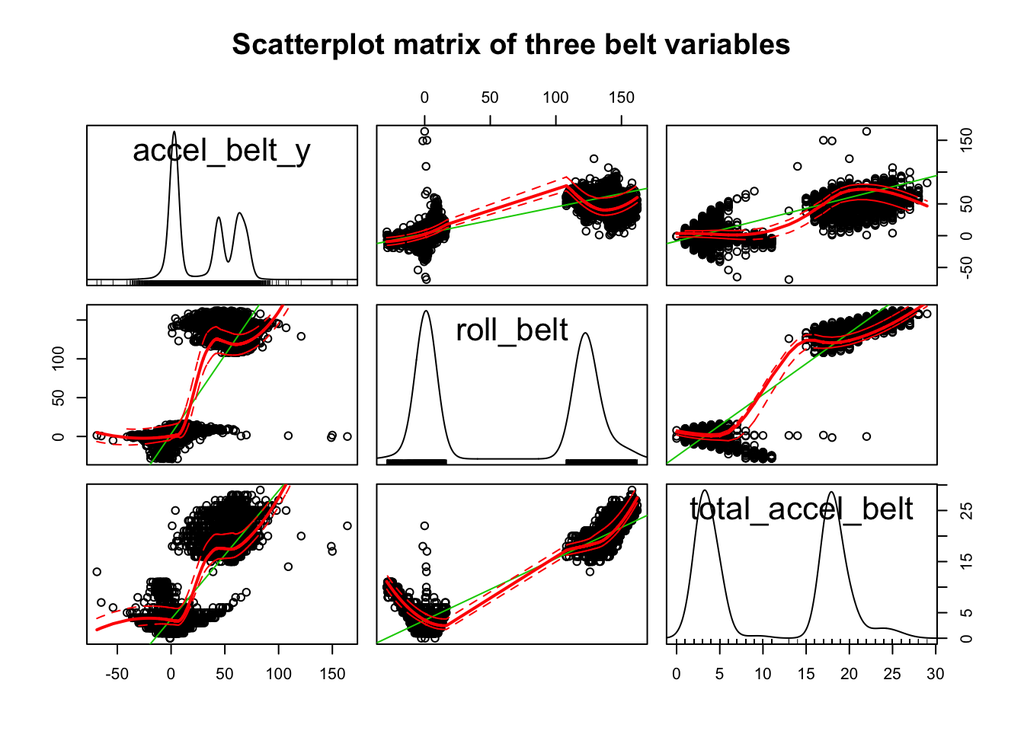

```r
library(car)
scatterplot.matrix(~accel_belt_y+roll_belt+total_accel_belt, data=training,
    main="Scatterplot matrix of three belt variables")
```

There appears to be some relationships between the variables, but I decided to let the algorithm to select which of these to use in the end model.

The algorithm I decided to use is random forest, because of its comparably higher accuracy. I ran the regression on all the remaining variables (after eliminating all NA columns and irrelevant columns).

For cross validation, I used K-fold cross validation, with K=10, and repeat it 3 times. This is because K-fold cross validation seems to work well, and K between 5 and 10 has been proved to be effective.

```r
control<-trainControl(method="repeatedcv",number=10, repeats=3)
```

Train the model:

```r
set.seed(32323)
modelrf<-train(classe ~ .,data=train, preProcess=c("center","scale"),method="rf",trControl=control)
test.pred<-predict(modelrf,tests)
```

Then, get a report of estimated out of sample errors， including accuracy and OOB estimated error.

```r
modelrf$finalModel
```

```
##
## Call:
##  randomForest(x = x, y = y, mtry = param$mtry)
##                Type of random forest: classification
##                      Number of trees: 500
## No. of variables tried at each split: 27
##
##         OOB estimate of  error rate: 0.25%
## Confusion matrix:
##      A    B    C    D    E  class.error
## A 3905    1    0    0    0 0.0002560164
## B   10 2645    3    0    0 0.0048908954
## C    0    5 2391    0    0 0.0020868114
## D    0    0   12 2239    1 0.0057726465
## E    0    0    0    3 2522 0.0011881188
```

```r
confusionMatrix(tests$classe,test.pred)
```

```
## Confusion Matrix and Statistics
##
##           Reference
## Prediction    A    B    C    D    E
##          A 1673    0    0    0    1
##          B    3 1133    2    1    0
##          C    0    2 1024    0    0
##          D    0    0    9  955    0
##          E    0    2    0    3 1077
##
## Overall Statistics
##
##                Accuracy : 0.9961
##                  95% CI : (0.9941, 0.9975)
##     No Information Rate : 0.2848
##     P-Value [Acc > NIR] : < 2.2e-16
##
##                   Kappa : 0.9951
##  Mcnemar's Test P-Value : NA
##
## Statistics by Class:
##
##                      Class: A Class: B Class: C Class: D Class: E
## Sensitivity            0.9982   0.9965   0.9894   0.9958   0.9991
## Specificity            0.9998   0.9987   0.9996   0.9982   0.9990
## Pos Pred Value         0.9994   0.9947   0.9981   0.9907   0.9954
## Neg Pred Value         0.9993   0.9992   0.9977   0.9992   0.9998
## Prevalence             0.2848   0.1932   0.1759   0.1630   0.1832
## Detection Rate         0.2843   0.1925   0.1740   0.1623   0.1830
## Detection Prevalence   0.2845   0.1935   0.1743   0.1638   0.1839
## Balanced Accuracy      0.9990   0.9976   0.9945   0.9970   0.9990
```

Finally, predict the 20 cases:

```r
answer.pred1<-predict(modelrf,testing)
Index<-1:20
results1=data.frame(Index,answer.pred1)
kable(results1)
```

[output not shown]